# COVID risk data source comparison

### Data sources:

- NHS 111 queries with suspect covid disposition Resolution: Postcode
- Primary care - confirmed and suspect cases STP
- UK linelist - confirmed cases LTLA
- A&E attendances (total only, not covid specific) STP
- ONS covid-related deaths (mentioned or underlying) LTLA
- Model-predicted cases NHS region

## 111 calls/online reports

Subset of MSOAs which all peak on 06/04 for rolling mean? Maybe some data missing for first few weeks?

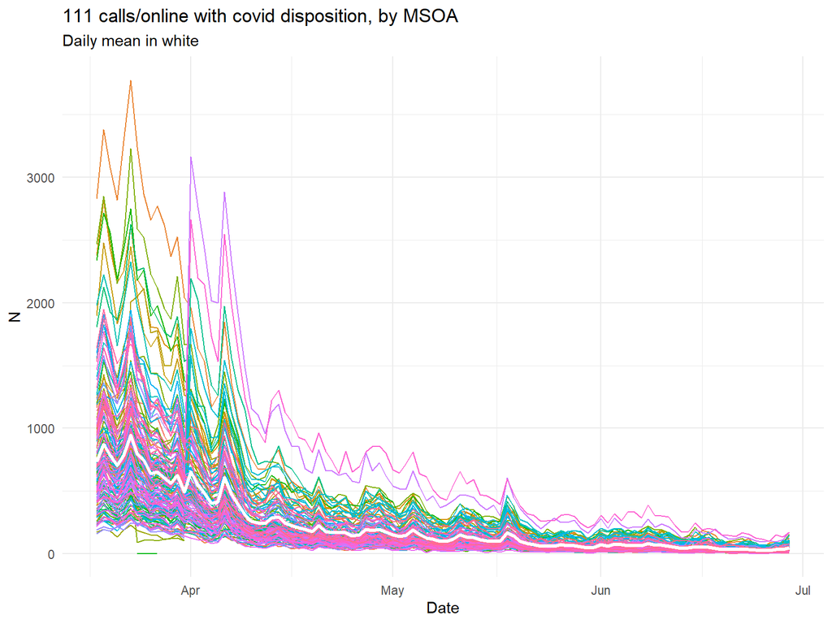

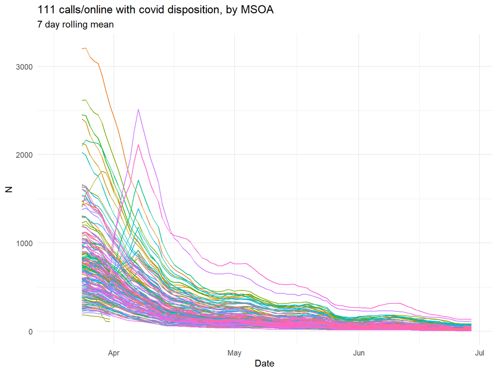

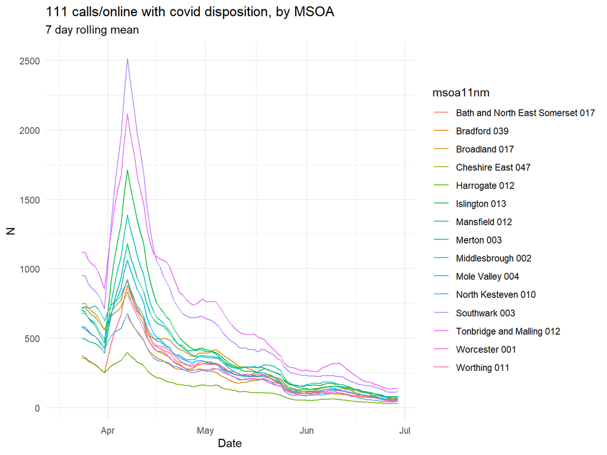

## UK Linelist (confirmed cases, pillar 1+2)

Two outlying series (increasing since June) are Leicester and Sheffield.

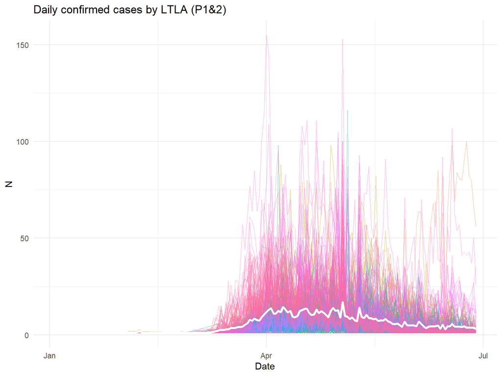

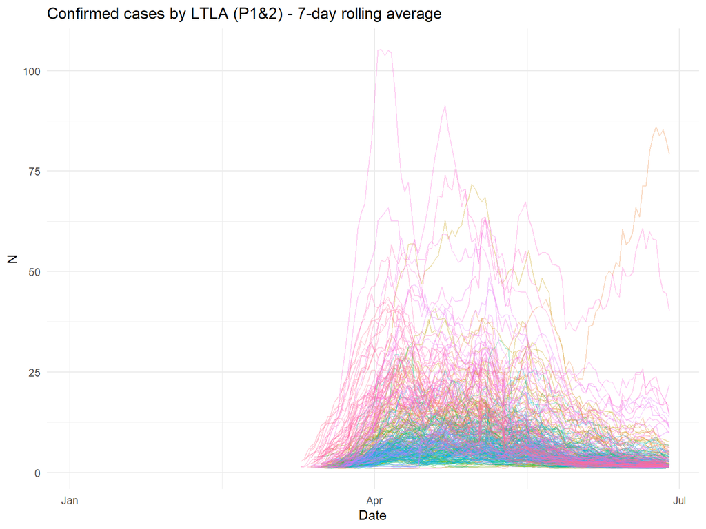

## ONS Covid-related deaths

Including cases with covid recorded as an underlying cause of death or just mentioned on death certificate.

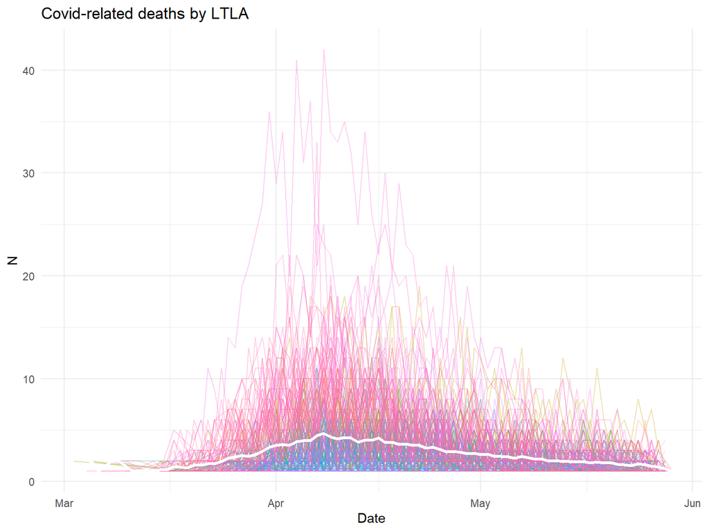

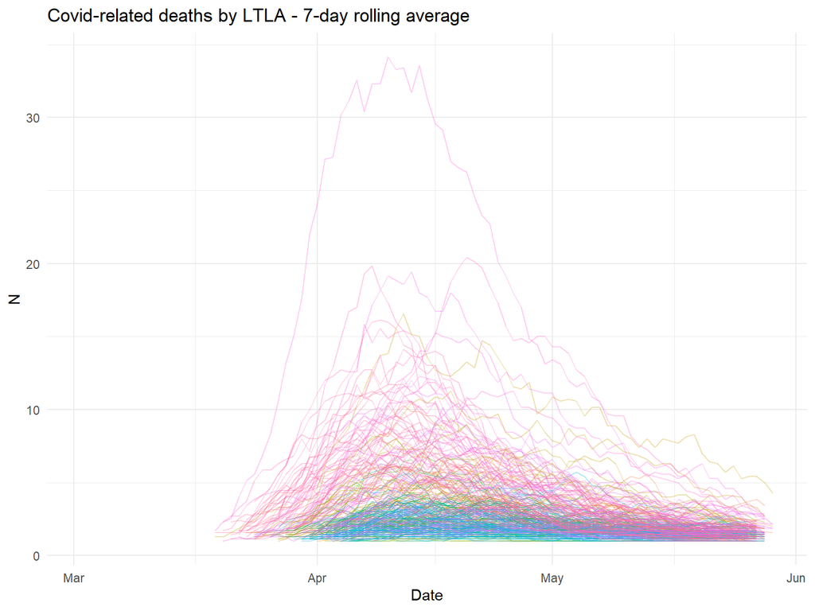

## Compare 111/linelist/deaths

In total over England.

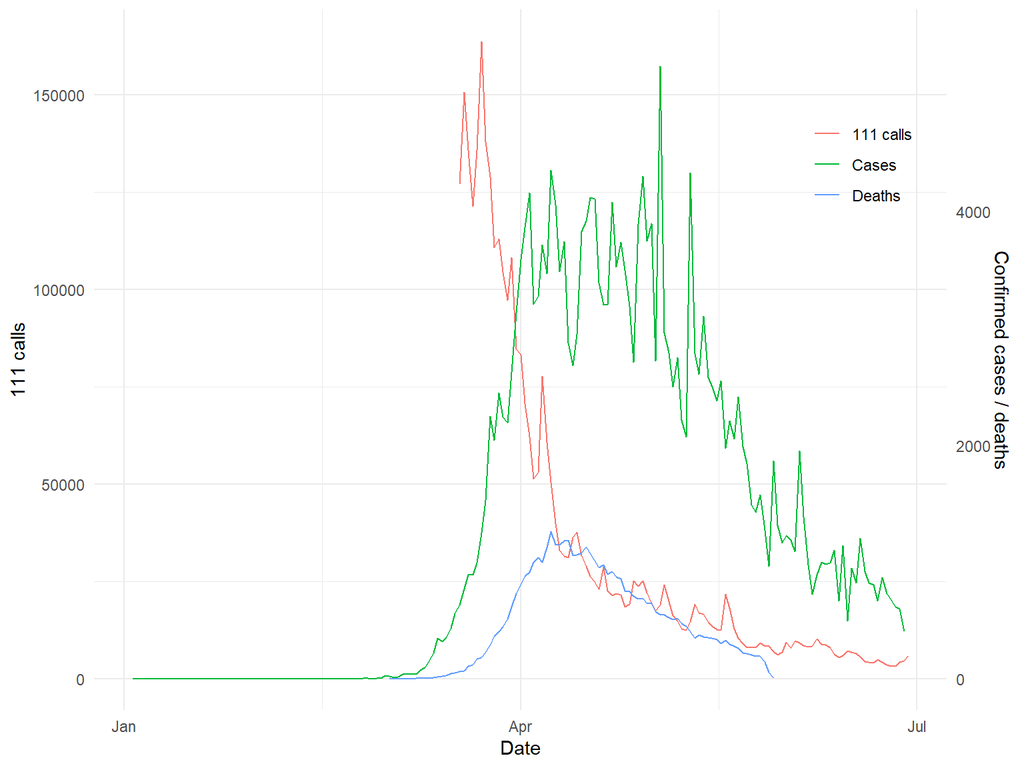

## Model-predicted cases

From big transmission model - available by NHS region and 5-year age bands. Originally fitted to death data.

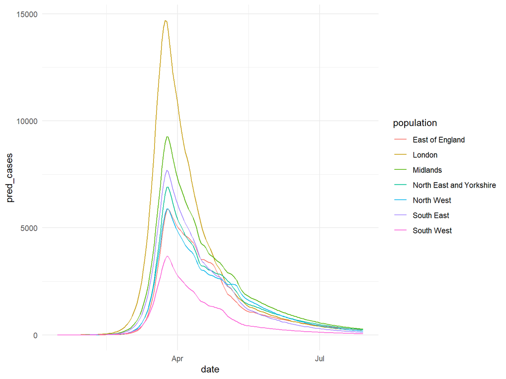

### Compare to ONS deaths by NHS region:

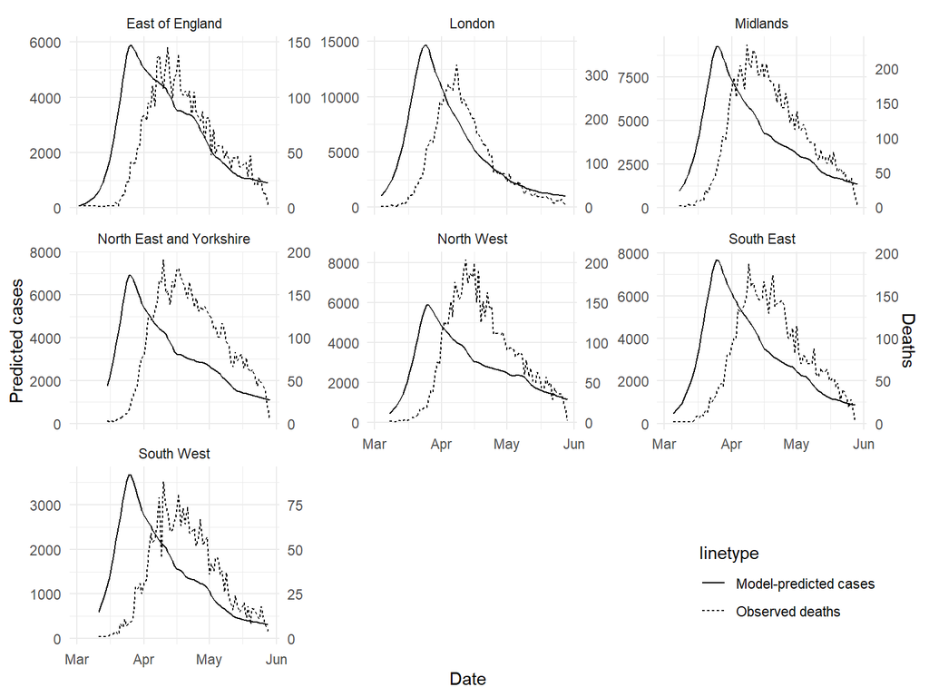

Approx 3 week lag between predicted case peak and death peak.

### Compare to 111 calls by NHS region:

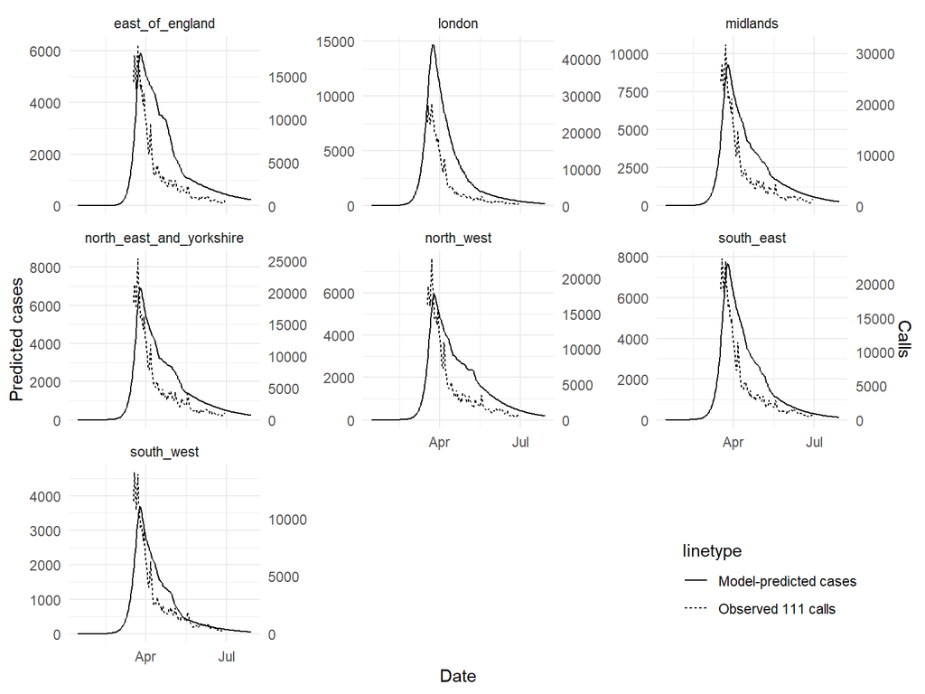

### Compare to confirmed cases from UK LL:

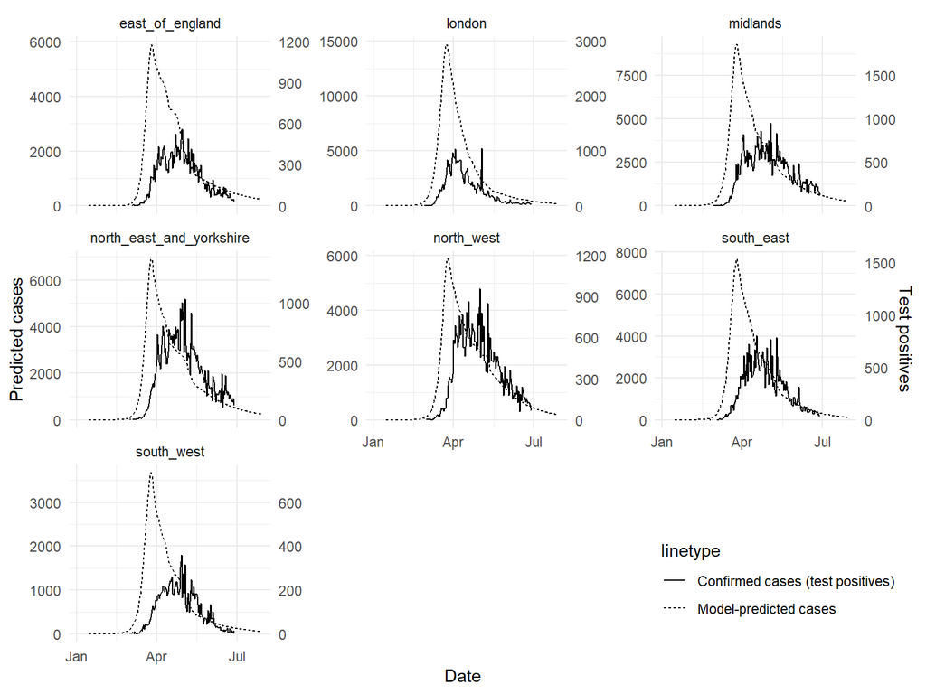

Approx 4 week lag. Does model predict cases at point of infection/symptom onset? UKLL recorded by date of lab report, so this lag related to testing delay?

## Opensafely EHR data

- A&E data reflect total attendances and only available up to 17/04.
- Death data reflect covid-underlying deaths only (?)

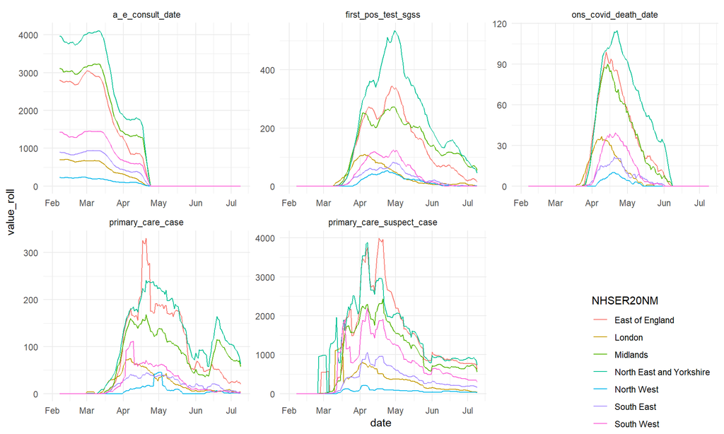

### Compare with model predictions:

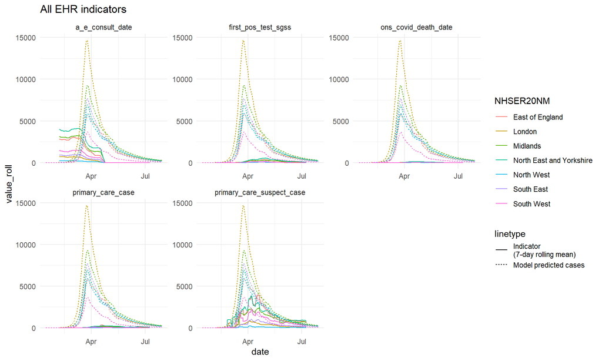

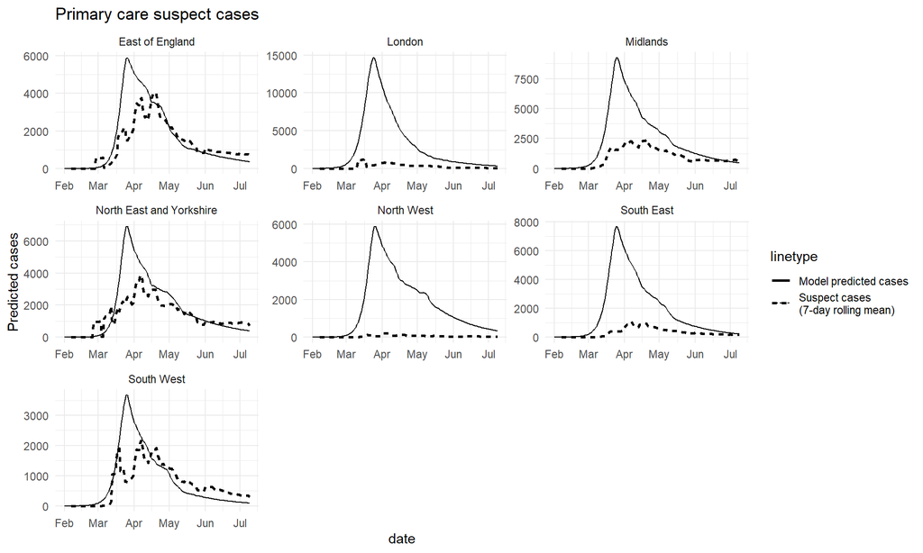

### Compare with calls:

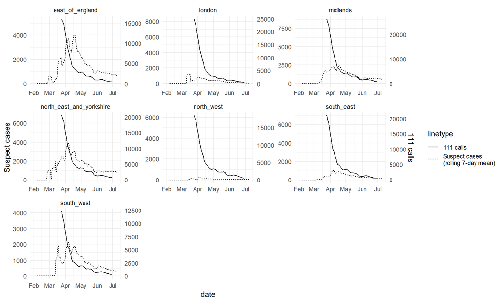

### Compare two death sources

Covid death indicator in OS includes only cases with covid as cause of death so lower.

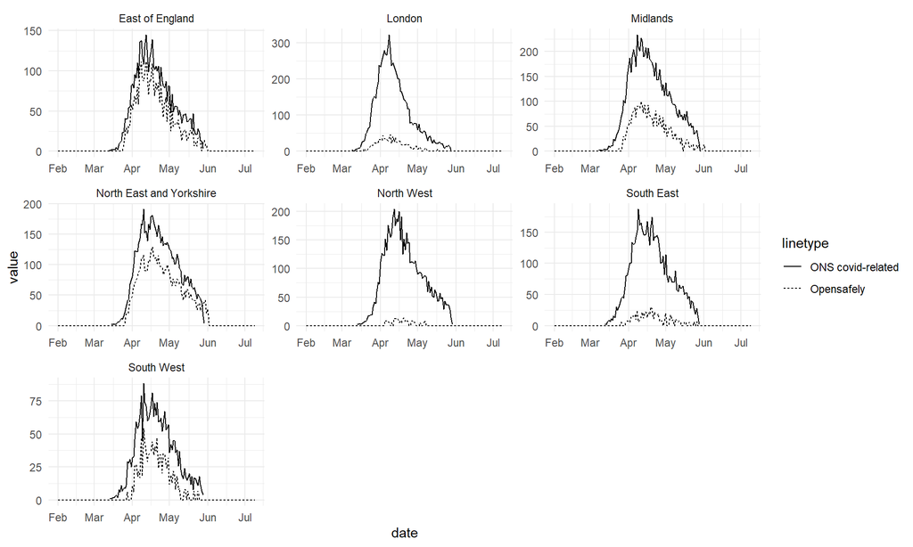